# Notes about Cluster Analysis

Luisa M. Mimmi

12 March, 2020

# Intro

This is a recap of what I have learned on cluster analysis. I basically reproduced examples found in various sources (acknowledged at bottom), to learn how to implement the algorithms in R.

# Brief theory about Cluster Analysis

GOAL: putting *like with like* It is considered `Exploratory Data Mining` bc it helps tease out relationships in large datasets

DIFFERENCE FROM CLASSIFICATION: `Classification` identifies and matches obs. with EXISTING label/group (spam vs non spam / cats vs dogs) – `Clustering` is “pragmatic grouping” done for a reason that make sense to me. (**THESE ARE NOT NATURAL GROUPINGS, THESE ARE GROUPS OF CONVENIENCE**). Its success depends on how well it serves my purpose.

(*) RESULTS WILL CHANGE A LOT DEPENDING ON THE VARIABLES YOU USE!!!!!! (*) Some of the algorithm REQUIRE CONTINUOUS DATA

EXAMPLES:

- marketing segmentation - similar customers to recommend the same things
- medicine - similar patients
- music - genre on playlist that I want together

ALGORITHMs:

- by **distance** (finds only convex clusters / these models are slow for big data…)
  - euclidean distance
  - connectivity models
  - hierarchical diagrams
  - joining or splitting
- by **distance from centroid** (only convex clusters / generally of similar size, you must pick k) `centroid is defined by a mean`
  - (mean for every group)
  - k-means clustering
- by **density of data** (connects dense regions and draw a perimeter around / )
  - connected dense regions in k-dimensions
  - it can model NON convex clusters
  - it is possible to sort of ignore outliers
  - hard to describe (by parametric distrib function)
- by **distributional model**
  - clusters as statistical distributions (ex. multivariate normal)
  - prone to overfitting
  - good to see correlations b/w attributes in data
  - limited to convex clusters

## Three major kinds of clustering:

1. `Hierarchical`: Start separate and combine
2. Split into set number of clusters (e.g., `kmeans`)
3. Dividing: Start with a single group and split

# EXAMPLES

I am using 2 differnt datasets:

```
1. a dataset `states` with searches made in collected at US states and information about 5 personality traits. Data and hypothesis taken from "Divided We Stand: Three Psychological Regions of the United States andTheir Political, Economic, Social, and Health Correlates" https://www.apa.org/pubs/jour…
2. a (subset of a) bank marketing dataset `bank`
```

# HIERARCHICAL CLUSTERING

### IV.a) Hierarchical clustering / `stats::hclust` / data = `states`

STEPS: 1. Create distance matrix (Euclidean) 2. PErform hierarchical cluster analysis on a set of dissimilarities (distance) 3. Plot

(*) Here only numeric variables are considered

```r
c # Info on clustering
```

```
Call:
hclust(d = d)

Cluster method   : complete
Distance         : euclidean
Number of objects: 48
```

### IV.b) Hierarchical clustering / `function` / data = mtcars

```r
# Conducting a cluster analysis
# Load data
#?mtcars
data(mtcars)
mtcars[1:5, ]
```

|  | mpg | cyl | disp | hp | drat | wt | qsec | vs | am | gear | carb |
| --- | --- | --- | --- | --- | --- | --- | --- | --- | --- | --- | --- |
| Mazda RX4 | 21.0 | 6 | 160 | 110 | 3.90 | 2.620 | 16.46 | 0 | 1 | 4 | 4 |
| Mazda RX4 Wag | 21.0 | 6 | 160 | 110 | 3.90 | 2.875 | 17.02 | 0 | 1 | 4 | 4 |
| Datsun 710 | 22.8 | 4 | 108 | 93 | 3.85 | 2.320 | 18.61 | 1 | 1 | 4 | 1 |
| Hornet 4 Drive | 21.4 | 6 | 258 | 110 | 3.08 | 3.215 | 19.44 | 1 | 0 | 3 | 1 |
| Hornet Sportabout | 18.7 | 8 | 360 | 175 | 3.15 | 3.440 | 17.02 | 0 | 0 | 3 | 2 |

```r
mtcars1 <- mtcars[, c(1:4, 6:7, 9:11)]  # Select variables
mtcars1[1:5, ]
```

|  | mpg | cyl | disp | hp | wt | qsec | am | gear | carb |
| --- | --- | --- | --- | --- | --- | --- | --- | --- | --- |
| Mazda RX4 | 21.0 | 6 | 160 | 110 | 2.620 | 16.46 | 1 | 4 | 4 |
| Mazda RX4 Wag | 21.0 | 6 | 160 | 110 | 2.875 | 17.02 | 1 | 4 | 4 |
| Datsun 710 | 22.8 | 4 | 108 | 93 | 2.320 | 18.61 | 1 | 4 | 1 |
| Hornet 4 Drive | 21.4 | 6 | 258 | 110 | 3.215 | 19.44 | 0 | 3 | 1 |
| Hornet Sportabout | 18.7 | 8 | 360 | 175 | 3.440 | 17.02 | 0 | 3 | 2 |

```r
# -------- We'll use hierarchical clustering
# Need distance matrix (dissimilarity matrix)
d <- dist(mtcars1)
head(d)  # Huge matrix
```

```
[1]   0.6153251  54.8994763  98.1039980 210.3361025  65.4542069 241.4066629
```

```r
# Use distance matrix for clustering
c <- hclust(d)
c
```

```
Call:
hclust(d = d)

Cluster method   : complete
Distance         : euclidean
Number of objects: 32
```

```r
# Plot dendrogram of clusters
plot(c)
# Put observations in groups
# Need to specify either k = groups or h = height
g3 <- cutree(c, k = 3)  # "g3" = "groups 3"
# cutree(hcmt, h = 230) will give same result
g3
```

```
          Mazda RX4       Mazda RX4 Wag          Datsun 710      Hornet 4 Drive   Hornet Sportabout
                  1                   1                   1                   2                   3
            Valiant          Duster 360           Merc 240D            Merc 230            Merc 280
                  2                   3                   1                   1                   1
          Merc 280C          Merc 450SE          Merc 450SL         Merc 450SLC  Cadillac Fleetwood
                  1                   2                   2                   2                   3
Lincoln Continental   Chrysler Imperial            Fiat 128         Honda Civic      Toyota Corolla
                  3                   3                   1                   1                   1
      Toyota Corona    Dodge Challenger         AMC Javelin          Camaro Z28    Pontiac Firebird
                  1                   2                   2                   3                   3
          Fiat X1-9       Porsche 914-2        Lotus Europa      Ford Pantera L        Ferrari Dino
                  1                   1                   1                   3                   1
      Maserati Bora          Volvo 142E
                  3                   1
```

```r
# Or do several levels of groups at once
# "gm" = "groups/multiple"
gm <- cutree(c, k = 2:5) # or k = c(2, 4)
gm
```

```
                    2 3 4 5
Mazda RX4           1 1 1 1
Mazda RX4 Wag       1 1 1 1
Datsun 710          1 1 1 1
Hornet 4 Drive      1 2 2 2
Hornet Sportabout   2 3 3 3
Valiant             1 2 2 2
Duster 360          2 3 3 3
Merc 240D           1 1 1 1
Merc 230            1 1 1 1
Merc 280            1 1 1 1
Merc 280C           1 1 1 1
Merc 450SE          1 2 2 2
Merc 450SL          1 2 2 2
Merc 450SLC         1 2 2 2
Cadillac Fleetwood  2 3 3 3
Lincoln Continental 2 3 3 3
Chrysler Imperial   2 3 3 3
Fiat 128            1 1 1 4
Honda Civic         1 1 1 4
Toyota Corolla      1 1 1 4
Toyota Corona       1 1 1 1
Dodge Challenger    1 2 2 2
AMC Javelin         1 2 2 2
Camaro Z28          2 3 3 3
Pontiac Firebird    2 3 3 3
Fiat X1-9           1 1 1 4
Porsche 914-2       1 1 1 1
Lotus Europa        1 1 1 1
Ford Pantera L      2 3 3 3
Ferrari Dino        1 1 1 1
Maserati Bora       2 3 4 5
Volvo 142E          1 1 1 1
```

```r
# Draw boxes around clusters
rect.hclust(c, k = 2, border = "gray")
```

```r
rect.hclust(c, k = 3, border = "blue")
rect.hclust(c, k = 4, border = "green4")
```

[figure not shown]

```r
rect.hclust(c, k = 5, border = "darkred")
```

# k-means CLUSTERING

### V) k-means Hierarchical clustering / `function` / data =

K-means clustering is an *unsupervised* machine learning algorithm for clustering `n` observations into `k` clusters where k is predefined or user-defined constant It finds the minimum total **distance** of obs. form the `centroid` of the (best) cluster (for all dimensions)

CONDITIONS:

- (only convex clusters similar size, you pick k)
- *hyperparameter* `k` = the number of clusters and has to be set beforehand. k should be picked as a # that is in the bal park of what you are willing to act on (eg. 5 if I want 5 segments of donors)
- Where (through an iterative approach) it finds:
  - The distance between data points within clusters should be as small as possible.
  - The distance of the centroids (= centres of the clusters) should be as big as possible.
- requires to scale the variables before clustering the data

APPLICATIONS: data that has a smaller number of dimensions, is numeric, and is continuous. such as document clustering, identifying crime-prone areas, customer segmentation, insurance fraud detection, public transport data analysis, clustering of IT alerts…etc.

### V.a) k-means Hierarchical clustering / `function` / data = mtcars

```r
# ======================================================
mtcars1 <- mtcars[, c(1:4, 6:7, 9:11)]  # Select variables
# k-means clustering - I pick 3 clusters
km <- stats::kmeans(mtcars1, centers=3)
km
```

```
K-means clustering with 3 clusters of sizes 7, 9, 16

Cluster means:
       mpg      cyl     disp       hp       wt     qsec        am     gear     carb
1 17.01429 7.428571 276.0571 150.7143 3.601429 18.11857 0.0000000 3.000000 2.142857
2 14.64444 8.000000 388.2222 232.1111 4.161556 16.40444 0.2222222 3.444444 4.000000
3 24.50000 4.625000 122.2937  96.8750 2.518000 18.54312 0.6875000 4.125000 2.437500

Clustering vector:
          Mazda RX4       Mazda RX4 Wag          Datsun 710      Hornet 4 Drive   Hornet Sportabout
                  3                   3                   3                   1                   2
            Valiant          Duster 360           Merc 240D            Merc 230            Merc 280
                  1                   2                   3                   3                   3
          Merc 280C          Merc 450SE          Merc 450SL         Merc 450SLC  Cadillac Fleetwood
                  3                   1                   1                   1                   2
Lincoln Continental   Chrysler Imperial            Fiat 128         Honda Civic      Toyota Corolla
                  2                   2                   3                   3                   3
      Toyota Corona    Dodge Challenger         AMC Javelin          Camaro Z28    Pontiac Firebird
                  3                   1                   1                   2                   2
          Fiat X1-9       Porsche 914-2        Lotus Europa      Ford Pantera L        Ferrari Dino
                  3                   3                   3                   2                   3
      Maserati Bora          Volvo 142E
                  2                   3

Within cluster sum of squares by cluster:
[1] 11844.51 46657.93 32833.43
 (between_SS / total_SS =  85.3 %)

Available components:

[1] "cluster"      "centers"      "totss"        "withinss"     "tot.withinss" "betweenss"    "size"
[8] "iter"         "ifault"
```

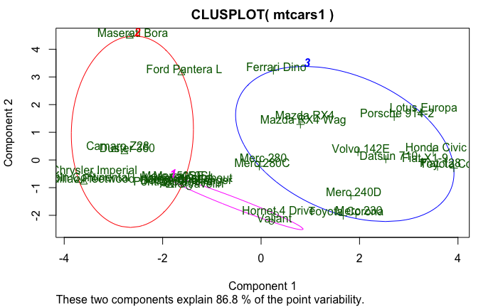

```r
# Graph based on k-means
require(cluster)
clusplot(mtcars1,  # data frame
         km$cluster,  # cluster data
         color = TRUE,  # color
#          shade = TRUE,  # Lines in clusters
         lines = 3,  # Lines connecting centroids
         labels = 2)  # Labels clusters and cases
```

```r
# here I get the centers
km$centers
```

```
       mpg      cyl     disp       hp       wt     qsec        am     gear     carb
1 17.01429 7.428571 276.0571 150.7143 3.601429 18.11857 0.0000000 3.000000 2.142857
2 14.64444 8.000000 388.2222 232.1111 4.161556 16.40444 0.2222222 3.444444 4.000000
3 24.50000 4.625000 122.2937  96.8750 2.518000 18.54312 0.6875000 4.125000 2.437500
```

```r
# here I get the cluster assignment (vector)
km$cluster
```

```
          Mazda RX4       Mazda RX4 Wag          Datsun 710      Hornet 4 Drive   Hornet Sportabout
                  3                   3                   3                   1                   2
            Valiant          Duster 360           Merc 240D            Merc 230            Merc 280
                  1                   2                   3                   3                   3
          Merc 280C          Merc 450SE          Merc 450SL         Merc 450SLC  Cadillac Fleetwood
                  3                   1                   1                   1                   2
Lincoln Continental   Chrysler Imperial            Fiat 128         Honda Civic      Toyota Corolla
                  2                   2                   3                   3                   3
      Toyota Corona    Dodge Challenger         AMC Javelin          Camaro Z28    Pontiac Firebird
                  3                   1                   1                   2                   2
          Fiat X1-9       Porsche 914-2        Lotus Europa      Ford Pantera L        Ferrari Dino
                  3                   3                   3                   2                   3
      Maserati Bora          Volvo 142E
                  2                   3
```

```r
# You can evaluate the clusters by looking at $totss and $betweenss.
km$totss
```

```
[1] 623370.7
```

```r
km$withinss # sum of the square of the distance from each data point to the cluster center.  Lower is better. (high withinss would indicate either outliers are in your data or you need to create more clusters.)
```

```
[1] 11844.51 46657.93 32833.43
```

```r
km$betweenss # sum of the squared distance between cluster centers.  Ideally you want cluster centers far apart from each other.
```

```
[1] 532034.9
```

```r
# ======================================================
# k-means clustering - I pick 5 clusters
km2 <- kmeans(mtcars1, 5)
km2
```

```
K-means clustering with 5 clusters of sizes 6, 7, 9, 9, 1

Cluster means:
       mpg      cyl      disp        hp       wt     qsec        am     gear     carb
1 16.83333 7.666667 284.56667 158.33333 3.625000 17.76833 0.0000000 3.000000 2.333333
2 20.61429 5.428571 166.81429 104.00000 3.167857 19.11429 0.2857143 3.857143 3.000000
3 27.34444 4.000000  96.55556  83.55556 2.089222 18.62333 0.8888889 4.111111 1.444444
4 14.64444 8.000000 388.22222 232.11111 4.161556 16.40444 0.2222222 3.444444 4.000000
5 19.70000 6.000000 145.00000 175.00000 2.770000 15.50000 1.0000000 5.000000 6.000000

Clustering vector:
          Mazda RX4       Mazda RX4 Wag          Datsun 710      Hornet 4 Drive   Hornet Sportabout
                  2                   2                   3                   1                   4
            Valiant          Duster 360           Merc 240D            Merc 230            Merc 280
                  2                   4                   2                   2                   2
          Merc 280C          Merc 450SE          Merc 450SL         Merc 450SLC  Cadillac Fleetwood
                  2                   1                   1                   1                   4
Lincoln Continental   Chrysler Imperial            Fiat 128         Honda Civic      Toyota Corolla
                  4                   4                   3                   3                   3
      Toyota Corona    Dodge Challenger         AMC Javelin          Camaro Z28    Pontiac Firebird
                  3                   1                   1                   4                   4
          Fiat X1-9       Porsche 914-2        Lotus Europa      Ford Pantera L        Ferrari Dino
                  3                   3                   3                   4                   5
      Maserati Bora          Volvo 142E
                  4                   3

Within cluster sum of squares by cluster:
[1]  6354.653  7283.756  7552.465 46657.934     0.000
 (between_SS / total_SS =  89.1 %)

Available components:

[1] "cluster"      "centers"      "totss"        "withinss"     "tot.withinss" "betweenss"    "size"
[8] "iter"         "ifault"
```

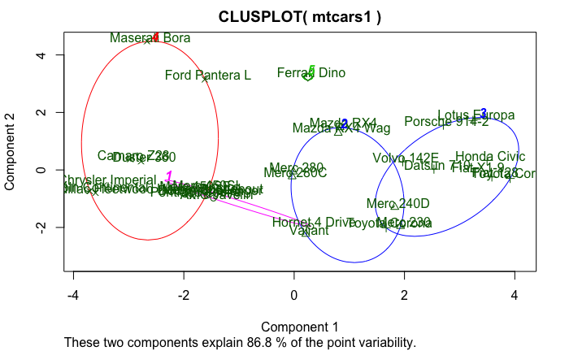

```r
# Graph based on k-means
require(cluster)
clusplot(mtcars1,  # data frame
         km2$cluster,  # cluster data
         color = TRUE,  # color
#          shade = TRUE,  # Lines in clusters
         lines = 3,  # Lines connecting centroids
         labels = 2)  # Labels clusters and cases
```

```r
 # here I get the centers
km2$centers
```

```
       mpg      cyl      disp        hp       wt     qsec        am     gear     carb
1 16.83333 7.666667 284.56667 158.33333 3.625000 17.76833 0.0000000 3.000000 2.333333
2 20.61429 5.428571 166.81429 104.00000 3.167857 19.11429 0.2857143 3.857143 3.000000
3 27.34444 4.000000  96.55556  83.55556 2.089222 18.62333 0.8888889 4.111111 1.444444
4 14.64444 8.000000 388.22222 232.11111 4.161556 16.40444 0.2222222 3.444444 4.000000
5 19.70000 6.000000 145.00000 175.00000 2.770000 15.50000 1.0000000 5.000000 6.000000
```

```r
# You can evaluate the clusters by looking at $totss and $betweenss.
km2$totss
```

```
[1] 623370.7
```

```r
km2$withinss # sum of the square of the distance from each data point to the cluster center.  Lower is better. (high withinss would indicate either outliers are in your data or you need to create more clusters.)
```

```
[1]  6354.653  7283.756  7552.465 46657.934     0.000
```

```r
km2$betweenss # sum of the squared distance between cluster centers.  Ideally you want cluster centers far apart from each other.
```

```
[1] 555521.9
```

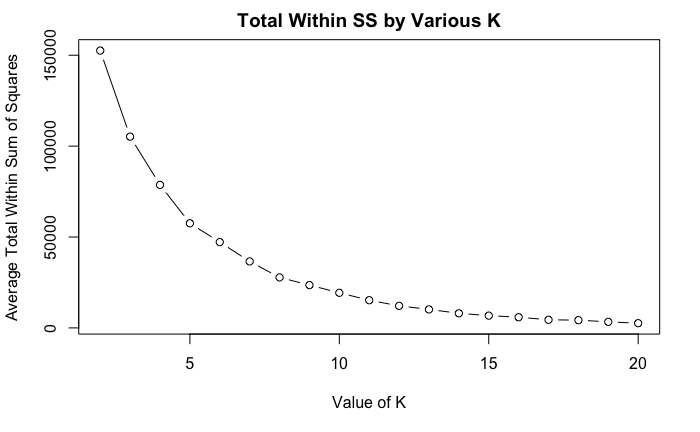

```r
# ======================================================
# Find ideal k
rng<-2:20 #K from 2 to 20
tries <-100 #Run the k Means algorithm 100 times
avg.totw.ss <-integer(length(rng)) #Set up an empty vector to hold all of points
for(v in rng){ # For each value of the range variable
 v.totw.ss <-integer(tries) #Set up an empty vector to hold the 100 tries
 for(i in 1:tries){
 k.temp <-kmeans(mtcars1,centers=v) #Run kmeans
 v.totw.ss[i] <-k.temp$tot.withinss#Store the total withinss
 }
 avg.totw.ss[v-1] <-mean(v.totw.ss) #Average the 100 total withinss
}
plot(rng,avg.totw.ss,type="b", main="Total Within SS by Various K",
 ylab="Average Total Within Sum of Squares",
 xlab="Value of K")
```

```r
# Somewhere around K = 5 we start losing dramatic gains.  So I’m satisfied with 5 clusters.
```

### V.b) k-means Hierarchical clustering / `function` / data =

Source: http://blog.ephorie.de/learning-data-science-understanding-and-using-k-means-clustering

http://www.learnbymarketing.com/tutorials/k-means-clustering-in-r-example/

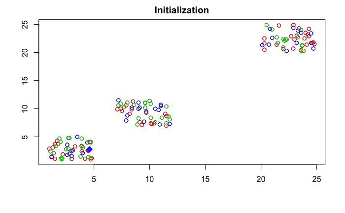

```r
n <- 3 # no. of centroids
set.seed(1415) # set seed for reproducibility

M1 <- matrix(round(runif(100, 1, 5), 1), ncol = 2)
M2 <- matrix(round(runif(100, 7, 12), 1), ncol = 2)
M3 <- matrix(round(runif(100, 20, 25), 1), ncol = 2)
M <- rbind(M1, M2, M3)

C <- M[1:n, ] # define centroids as first n objects
obs <- length(M) / 2
A <- sample(1:n, obs, replace = TRUE) # assign objects to centroids at random
colors <- seq(10, 200, 25)
# helper function for plotting the steps
clusterplot <- function(M, C, txt) {
  plot(M, main = txt, xlab = "", ylab = "")
  for(i in 1:n) {
    points(C[i, , drop = FALSE], pch = 23, lwd = 3, col = colors[i])
    points(M[A == i, , drop = FALSE], col = colors[i])
  }
}
clusterplot(M, C, "Initialization")
```

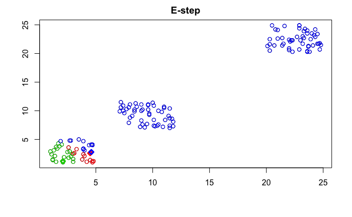

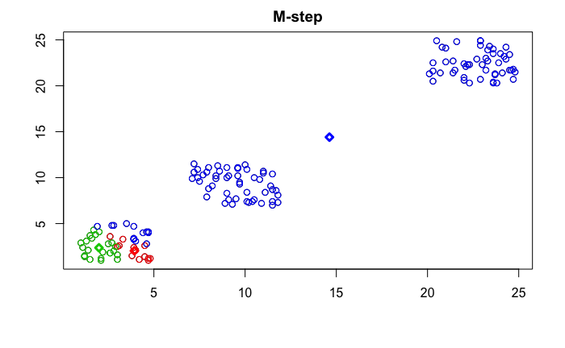

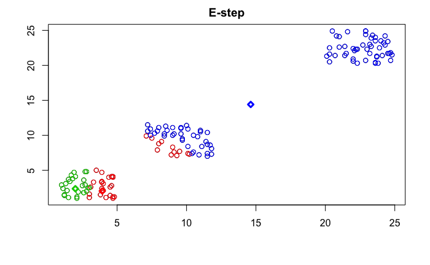

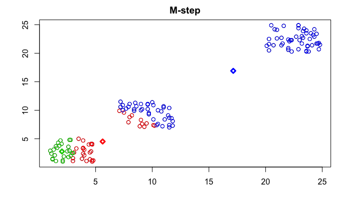

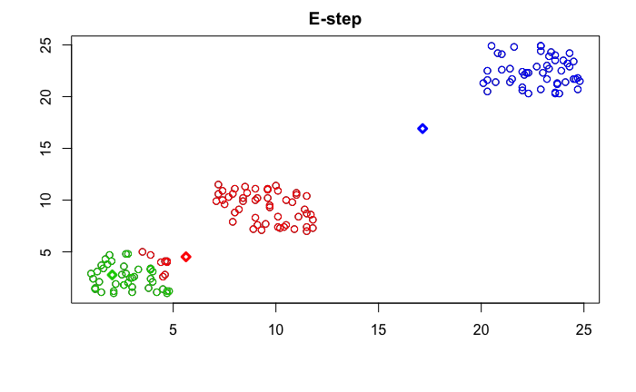

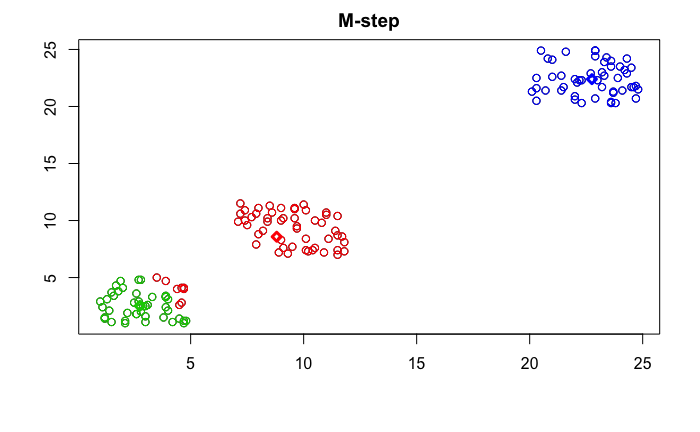

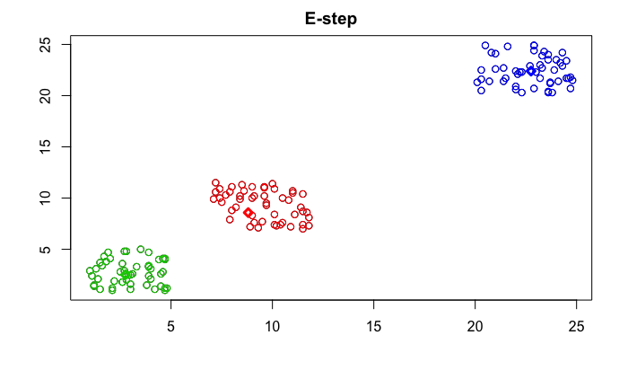

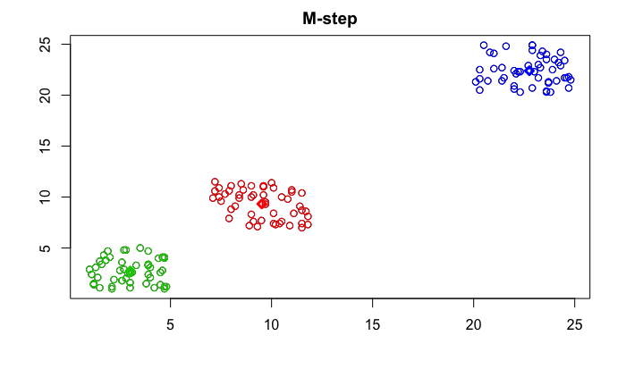

```r
#------------k-means algorithm iterative
# diamonds are the Centroids
repeat {
  # calculate Euclidean distance between objects and centroids
  D <- matrix(data = NA, nrow = n, ncol = obs)
  for(i in 1:n) {
    for(j in 1:obs) {
      D[i, j] <- sqrt((M[j, 1] - C[i, 1])^2 + (M[j, 2] - C[i, 2])^2)
    }
  }
  O <- A

  ## E-step: parameters are fixed, distributions are optimized
  A <- max.col(t(-D)) # assign objects to centroids
  if(all(O == A)) break # if no change stop
  clusterplot(M, C, "E-step")

  ## M-step: distributions are fixed, parameters are optimized
  # determine new centroids based on mean of assigned objects
  for(i in 1:n) {
    C[i, ] <- apply(M[A == i, , drop = FALSE], 2, mean)
  }
  clusterplot(M, C, "M-step")
}
```

```r
#Check results
(custom <- C[order(C[ , 1]), ])
```

```
       [,1]   [,2]
[1,]  3.008  2.740
[2,]  9.518  9.326
[3,] 22.754 22.396
```

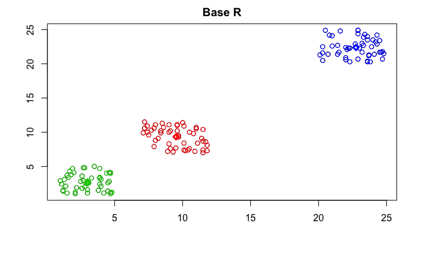

```r
##        [,1]   [,2]
## [1,]  3.008  2.740
## [2,]  9.518  9.326
## [3,] 22.754 22.396
#------------k-means algorithm BASE R
cl <- kmeans(M, n)
clusterplot(M, cl$centers, "Base R")
```

```r
#Check results
(base <- cl$centers[order(cl$centers[ , 1]), ])
```

```
    [,1]   [,2]
2  3.008  2.740
1  9.518  9.326
3 22.754 22.396
```

```r
##     [,1]   [,2]
## 2  3.008  2.740
## 1  9.518  9.326
## 3 22.754 22.396
# same!
```

### VI) PAM (partitioning around medoids) clustering/ `function` / data = bank

Source: https://towardsdatascience.com/clustering-on-mixed-type-data-8bbd0a2569c3 copied from(?)http://dpmartin42.github.io/posts/r/cluster-mixed-types

#### Example k-medoids (Partitioning around medoids) with bank marketing dataset

In the context of unsupervised classification, we may need to analyze datasets made of `mixed-type data`, where numeric, nominal (categorical, not ordered) or ordinal (categorical, ordered) features coexist.

- similarity measured with distance (`Gower distance` ~ avg of partial dissimilarity ranges )
- PAM clustering algorithm (partitioning around medoids)
- `k-medoid` is a classical partitioning technique of clustering that clusters the data set of n objects into k clusters known a priori.
- `silhouette coefficient` is used to determine optimal # of clusters (we don’t know a priori)
- bank marketing dataset

We first need to define some notion of (dis)similarity between observations. A popular choice for clustering is Euclidean distance, but only valid for continuous variables We have to use a distance metric that can handle mixed data types –> `Gower distance`.

```
* pros: Intuitive to understand and straightforward to calculate
* cons: Sensitive to non-normality and outliers in continuous variables --> transformations as a pre-processing step might be necessary.
```

```r
df[ ,Factors] <-  lapply( df[ ,Factors], as.factor)
```

[output not shown]

We use `Partitioning around medoids (PAM) clustering algorithm` = an iterative clustering procedure with the following steps:

1. Choose k random entities to become the medoids
2. Assign every entity to its closest medoid (using our custom distance matrix in this case)
3. For each cluster, identify the observation that would yield the lowest average distance if it were to be re-assigned as the medoid. If so, make this observation the new medoid.
4. If at least one medoid has changed, return to step 2. Otherwise, end the algorithm.

The `silhouette coefficient` contrasts the average distance to elements in the same cluster with the average distance to elements in other clusters. Objects with a high silhouette value are considered well clustered, objects with a low value may be outliers. This index works well with k-medoids clustering, and is also used to determine the optimal number of clusters. Please read the Wikipedia page for further details around computation and interpretation.

Cluster Interpretation

```r
#Summary of each cluster
k <- 3
pam_fit <- pam(gower_dist, diss = TRUE, k)
pam_results <- df %>%
  mutate(cluster = pam_fit$clustering) %>%
  group_by(cluster) %>%
  do(the_summary = summary(.))
pam_results$the_summary
```

```
[[1]]
      age                   job          marital        education    default       balance        housing
 Min.   :19.00   management   :748   divorced:174   primary  : 207   no :1569   Min.   :-1313.0   no :1257
 1st Qu.:34.00   technician   :166   married :949   secondary: 303   yes:  21   1st Qu.:   83.0   yes: 333
 Median :41.00   retired      :117   single  :467   tertiary :1000              Median :  558.5
 Mean   :42.93   blue-collar  :100                  unknown  :  80              Mean   : 1801.5
 3rd Qu.:51.00   admin.       : 96                                              3rd Qu.: 1908.2
 Max.   :87.00   self-employed: 78                                              Max.   :71188.0
                 (Other)      :285
  loan           contact          day            month        duration         campaign         pdays
 no :1416   cellular :1341   Min.   : 1.00   aug    :517   Min.   :   5.0   Min.   : 1.00   Min.   : -1
 yes: 174   telephone: 125   1st Qu.:11.00   nov    :217   1st Qu.: 104.0   1st Qu.: 1.00   1st Qu.: -1
            unknown  : 124   Median :19.00   jul    :160   Median : 175.5   Median : 2.00   Median : -1
                             Mean   :17.66   may    :146   Mean   : 257.1   Mean   : 2.95   Mean   : 37
                             3rd Qu.:25.00   jun    :143   3rd Qu.: 314.0   3rd Qu.: 3.00   3rd Qu.: -1
                             Max.   :31.00   apr    :101   Max.   :3025.0   Max.   :29.00   Max.   :871
                                             (Other):306
    previous          poutcome      y           cluster
 Min.   : 0.0000   failure: 176   no :1330   Min.   :1
 1st Qu.: 0.0000   other  :  75   yes: 260   1st Qu.:1
 Median : 0.0000   success:  67              Median :1
 Mean   : 0.6013   unknown:1272              Mean   :1
 3rd Qu.: 0.0000                             3rd Qu.:1
 Max.   :22.0000                             Max.   :1


[[2]]
      age                 job          marital        education    default       balance        housing
 Min.   :19.00   technician :442   divorced:162   primary  : 125   no :1337   Min.   :-2082.0   no :423
 1st Qu.:32.00   admin.     :225   married :787   secondary:1056   yes:  30   1st Qu.:   39.5   yes:944
 Median :36.00   services   :187   single  :418   tertiary : 156              Median :  389.0
 Mean   :38.97   blue-collar:183                  unknown  :  30              Mean   : 1194.2
 3rd Qu.:46.00   management : 65                                              3rd Qu.: 1238.5
 Max.   :80.00   retired    : 60                                              Max.   :26452.0
                 (Other)    :205
  loan           contact          day            month        duration         campaign          pdays
 no :1075   cellular :1251   Min.   : 1.00   jul    :517   Min.   :   5.0   Min.   : 1.000   Min.   : -1.00
 yes: 292   telephone:  82   1st Qu.: 8.00   may    :178   1st Qu.: 107.5   1st Qu.: 1.000   1st Qu.: -1.00
            unknown  :  34   Median :15.00   apr    :162   Median : 192.0   Median : 2.000   Median : -1.00
                             Mean   :15.18   nov    :147   Mean   : 268.7   Mean   : 2.698   Mean   : 54.22
```

[output cut: 21 more lines]

```
  loan           contact          day            month         duration         campaign          pdays
 no :1339   cellular : 304   Min.   : 1.00   may    :1074   Min.   :   4.0   Min.   : 1.000   Min.   : -1.00
 yes: 225   telephone:  94   1st Qu.: 8.00   jun    : 335   1st Qu.: 100.0   1st Qu.: 1.000   1st Qu.: -1.00
            unknown  :1166   Median :14.00   apr    :  30   Median : 192.0   Median : 2.000   Median : -1.00
                             Mean   :14.79   jul    :  29   Mean   : 266.8   Mean   : 2.718   Mean   : 29.95
                             3rd Qu.:20.00   feb    :  26   3rd Qu.: 332.0   3rd Qu.: 3.000   3rd Qu.: -1.00
                             Max.   :31.00   nov    :  25   Max.   :2456.0   Max.   :32.000   Max.   :808.00
                                             (Other):  45
    previous          poutcome      y           cluster
 Min.   : 0.0000   failure: 115   no :1472   Min.   :3
 1st Qu.: 0.0000   other  :  44   yes:  92   1st Qu.:3
 Median : 0.0000   success:  16              Median :3
 Mean   : 0.3542   unknown:1389              Mean   :3
 3rd Qu.: 0.0000                             3rd Qu.:3
 Max.   :25.0000                             Max.   :3
```

```r
# BTW, in PAM alg, medoids serve as exemplars of each clusters
df[pam_fit$medoids,]
```

| age | job | marital | education | default | balance | housing | loan | contact | day | month | duration | campaign | pdays | previous | poutcome | y |
| --- | --- | --- | --- | --- | --- | --- | --- | --- | --- | --- | --- | --- | --- | --- | --- | --- |
| 40 | management | married | tertiary | no | 51 | no | no | cellular | 19 | aug | 164 | 2 | -1 | 0 | unknown | no |
| 34 | technician | married | secondary | no | 0 | yes | no | cellular | 15 | jul | 144 | 1 | -1 | 0 | unknown | no |
| 41 | blue-collar | married | secondary | no | 641 | yes | no | unknown | 13 | may | 161 | 1 | -1 | 0 | unknown | no |

Visualization in a lower dimensional space wwith t-distributed stochastic neighborhood embedding, or `t-SNE`

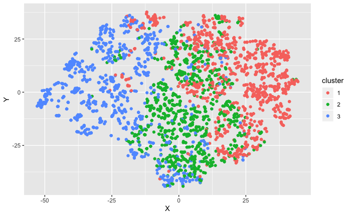

```r
# t-SNE = dimension reduction technique that tries to preserve local structure to make clusters visible in a 2D or 3D visualization. While typically utilizes Euclidean distance, it can handle a custom distance metric
tsne_obj <- Rtsne(gower_dist, is_distance = TRUE)
tsne_data <- tsne_obj$Y %>%
  data.frame() %>%
  setNames(c("X", "Y")) %>%
  mutate(cluster = factor(pam_fit$clustering))
ggplot(aes(x = X, y = Y), data = tsne_data) +
  geom_point(aes(color = cluster))
```

Alternatives (for clustering mixed data): https://www.researchgate.net/publication/323422280_kamila_Clustering_Mixed-Type_Data_in_R_and_Hadoop

# Resources

- LinkedIn Premium course “Data Mining”https://www.linkedin.com/learning/data-science-foundations-data-mining/clustering-in-r
- https://www.kdnuggets.com/2016/09/comparing-clustering-techniques-concise-technical-overview.html
- http://www.learnbymarketing.com/tutorials/ (kmeans clustering)
- https://www.datasciencecentral.com/profiles/blogs/14-great-articles-and-tutorials-on-clustering
- IADB ML course
- Hastie, Tibshirani, Firedman “The elements of Statistical Learning”, 2009